# inversiones2 slides

En la siguiente presentación se mostraran los resultados de analizar las distintas empresas que conforman el índice SP500 a lo largo del tiempo para recomendar las mejores empresas, y poder tomar decisiones en base a nuestras recomendaciones.

Librerías usadas en el desarrollo:

```python
import bs4 as bs
import pickle
import requests
import datetime as dt
import os
import pandas as pd
import numpy as np
import seaborn as sns
import matplotlib.pyplot as plt
import matplotlib.dates as mdates
import pandas as pd
import yfinance as yf
import datetime
import plotly.express as px
import ssl
ssl._create_default_https_context = ssl._create_unverified_context
```

Análisis

Rendimiento Gap

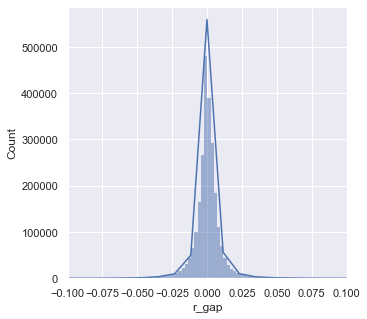

```python
sns.set(rc={'figure.figsize':(5,5)})
fig = plt.figure()
ax = plt.axes()
sns.histplot(data["r_gap"], bins=1000,kde=True)
plt.xlim(-0.1, 0.1)
plt.show()
```

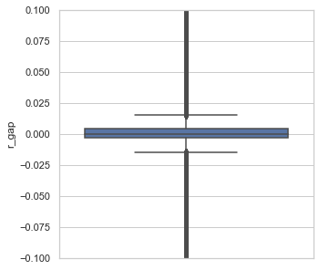

```python
sns.set(rc={'figure.figsize':(5,5)})
sns.set_theme(style="whitegrid")
ax = sns.boxplot(y=data["r_gap"])
plt.ylim(-0.1, 0.1)
plt.show()
```

RENDIMIENTO INTRADARIO

```
(-0.1, 0.1)
```

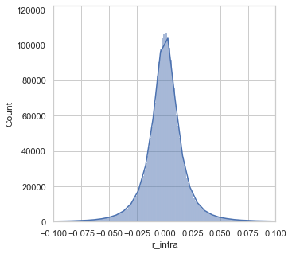

```python
fig = plt.figure()
ax = plt.axes()
sns.histplot(data["r_intra"], bins=1000, kde=True)
plt.xlim(-0.1, 0.1)
```

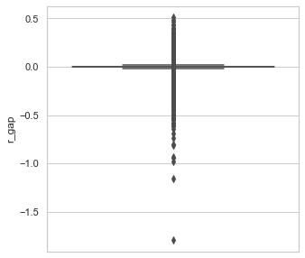

```python
sns.set_theme(style="whitegrid")
ax = sns.boxplot(y=data["r_gap"])
```

Variación

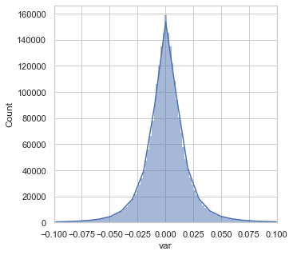

```python
fig = plt.figure()
ax = plt.axes()
sns.histplot(data["var"], bins=1000, kde=True)
plt.xlim(-0.1, 0.1)
plt.show()
```

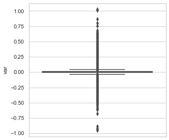

```python
sns.set_theme(style="whitegrid")
ax = sns.boxplot(y=data["var"])
```

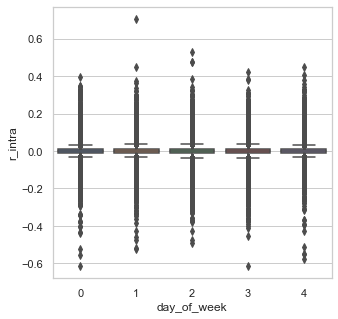

```python
ax = sns.boxplot(x="day_of_week", y="r_intra", data=data)
```

¿Cual es el mejor día para invertir teniendo en cuenta el retorno de los movimiento gap?

```python
data4.sort_values('r_gap', ascending=False)
```

|  | day_of_week | r_gap | dias_semanas |
| --- | --- | --- | --- |
| 1 | 1 | 0.000578 | Martes |
| 4 | 4 | 0.000223 | Viernes |
| 2 | 2 | 0.000115 | Miercoles |
| 3 | 3 | 0.000057 | Jueves |
| 0 | 0 | 0.000041 | Lunes |

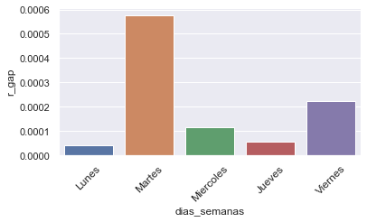

```python
sns.set(rc={'figure.figsize':(6,3)})
plt.xticks(fontsize=12,rotation=45)
sns.barplot(data = data4, x='dias_semanas', y='r_gap')
plt.show()
#Compraria el lunes porque el martes abre alto
```

¿Cual es el mejor día para invertir teniendo en cuenta el retorno de los movimientos intradiarios?

```python
data5.sort_values('r_intra',ascending=False )
#El dia con mejor rendimiento intradiario es el jueves.
```

|  | day_of_week | r_intra | dias_semanas |
| --- | --- | --- | --- |
| 3 | 3 | 0.000520 | Jueves |
| 4 | 4 | 0.000250 | Viernes |
| 2 | 2 | 0.000239 | Miercoles |
| 1 | 1 | 0.000187 | Martes |
| 0 | 0 | -0.000307 | Lunes |

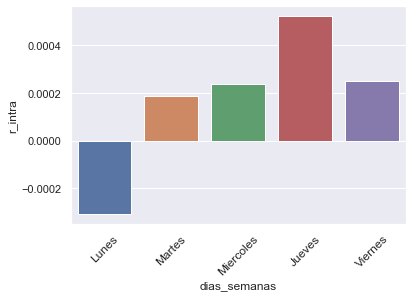

```python
sns.set(rc={'figure.figsize':(6,4)})
plt.xticks(fontsize=12,rotation=45)
sns.barplot(data = data5, x='dias_semanas', y='r_intra')
plt.show()
#Compraria el jueves a la mañana
```

¿Cuales son las mejores industrias que pertenecen al SP500 en las cuales se puede invertir?

Mi criterio va a ser ver la cantidad de empresas por sector, los sectores con más empresas serán los elegidos para invertir.

```python
distribucion
```

|  | index | GICS | Porcentaje |
| --- | --- | --- | --- |
| 0 | Information Technology | 74 | 14.741036 |
| 1 | Industrials | 73 | 14.541833 |
| 2 | Financials | 66 | 13.147410 |
| 3 | Health Care | 64 | 12.749004 |
| 4 | Consumer Discretionary | 58 | 11.553785 |
| 5 | Consumer Staples | 33 | 6.573705 |
| 6 | Real Estate | 31 | 6.175299 |
| 7 | Utilities | 28 | 5.577689 |
| 8 | Materials | 28 | 5.577689 |
| 9 | Communication Services | 26 | 5.179283 |
| 10 | Energy | 21 | 4.183267 |

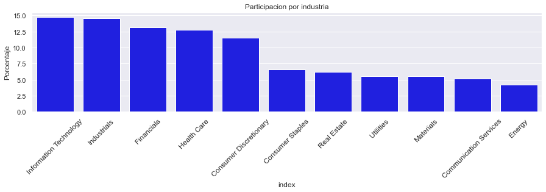

```python
sns.set(rc={'figure.figsize':(15,3)})
plt.xticks(fontsize=12,rotation=45)
sns.barplot(data = distribucion, x='index', y='Porcentaje', color="blue").set(title="Participacion por industria")
plt.show()
```

Las empresas que mayor participación tienen en el índice son las IT, seguido por Industrials y financials. Recomendaría invertir en el top 5 de estas categorías.

¿Cuáles fueron los momentos de alta volatilidad que afectaron al SP500?

```python
data_volatil2.loc[data_volatil2['var'] == data_volatil2["var"].max()]
```

|  | Date | var |
| --- | --- | --- |
| 5089 | 2020-03-24 00:00:00 | 0.115781 |

```python
data_volatil2.loc[data_volatil2['var'] == data_volatil2["var"].min()]
```

|  | Date | var |
| --- | --- | --- |
| 5083 | 2020-03-16 00:00:00 | -0.126881 |

El periodo más volátil fue marzo de 2020, teniendo los picos de variación, tanto positiva como negativa.

[figure not shown]

En los gráficos anteriores se ve como fue evolucionando la volatilidad a través de los años, se pueden observar periodos turbulentos en el año 2008, de más larga duración, y en el 2020 se observa un periodo más volátil pero más corto.

¿Cuales son las 9 mejores empresas para invertir?

El perfil de la empresa es cuidar su dinero, buscaremos acciones que más crecieron en los últimos 6 meses.

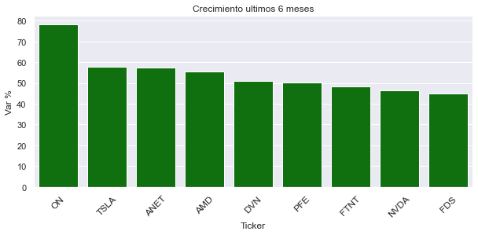

```python
data_top_9 = data.copy()
data_parcial = data_top_9[data_top_9["Date"] >= '2021-07-01 00:00:00']
data_parcial=data_parcial.drop(["Open","High","Low","Close","Volume","GICS","day_of_week","r_intra","r_gap","var","var log","Volatility"], axis=1)
data_parcial_min = data_parcial[data_parcial["Date"] == data_parcial["Date"].min()]
data_parcial_max = data_parcial[data_parcial["Date"] == data_parcial["Date"].max()]
data_parcial_dif = pd.merge(data_parcial_min,data_parcial_max, on=["Ticker"])
data_parcial_dif["Var %"] = data_parcial_dif.apply(lambda row: (((row["Adj Close_y"]/row["Adj Close_x"])-1)*100), axis = 1).fillna(0)
data_parcial_dif = data_parcial_dif.sort_values("Var %", ascending=False)
data_parcial_dif = data_parcial_dif.head(9)
data_parcial_dif = data_parcial_dif.drop(["Date_x","Adj Close_x","Date_y","Adj Close_y"], axis=1)
sns.set(rc={'figure.figsize':(10,4)})
plt.xticks(fontsize=12,rotation=45)
sns.barplot(data = data_parcial_dif, x='Ticker', y='Var %', color="green").set(title="Crecimiento ultimos 6 meses")
plt.show()
```